# Project Python Foundations: FoodHub Data Analysis

### **Question 7**: Which are the top 5 restaurants in terms of the number of orders received? [1 mark]

```python
# Print some preliminary info - total number of orders and how many restaurants in the data set.
print("Total number of orders:", data['order_id'].count())
print("Total number of restaurents:", data['restaurant_name'].nunique())
# Using value_counts(), print the number of rows per unique restaurant name.
# value_count() function has sort=True by default hence it will sort the rows by count value in descending order
data['restaurant_name'].value_counts()
```

```
Total number of orders: 1898
Total number of restaurents: 178
```

| restaurant_name | count |
| --- | --- |
| Shake Shack | 219 |
| The Meatball Shop | 132 |
| Blue Ribbon Sushi | 119 |
| Blue Ribbon Fried Chicken | 96 |
| Parm | 68 |
| ... | ... |
| Sushi Choshi | 1 |
| Dos Caminos Soho | 1 |
| La Follia | 1 |
| Philippe Chow | 1 |
| 'wichcraft | 1 |

178 rows × 1 columns

**dtype:** int64

#### **Observations**: From the above data, we can see that the top five restaurants that received the highest number of orders are Shake Shack-219, The Meatball Shop-132, Blue Ribbon Sushi-119, Blue Ribbon Fried Chicken-96, and Parm-68.

### **Question 8**: Which is the most popular cuisine on weekends? [1 mark]

```python
# Print how many unique cousines exist in the data set.
print("Total number of cuisine type:", data['cuisine_type'].nunique())
# First filter the data set by column value 'day_of_the_week' == 'Weekend'.
# Then use value_counts(), to print the number of orders per unique 'cousine_type' using the filtered data for Weekends.
# value_count() function has sort=True by default, hence it will sort the rows by count value in descending order.
data[data['day_of_the_week'] == 'Weekend']['cuisine_type'].value_counts()
```

```
Total number of cuisine type: 14
```

| cuisine_type | count |
| --- | --- |
| American | 415 |
| Japanese | 335 |
| Italian | 207 |
| Chinese | 163 |
| Mexican | 53 |
| Indian | 49 |
| Mediterranean | 32 |
| Middle Eastern | 32 |
| Thai | 15 |
| French | 13 |
| Korean | 11 |
| Southern | 11 |
| Spanish | 11 |
| Vietnamese | 4 |

**dtype:** int64

#### **Observations**: From the above analysis, we can see that American is the most popular cousine in the weekends.

### **Question 9**: What percentage of the orders cost more than 20 dollars? [2 marks]

```python
# Frist count the number of orders when 'cost_of_the_order' > 20
# Second count total number of orders
# Devide first by second cont and multiply by 100 to get the percentage.
data[data['cost_of_the_order'] > 20]['order_id'].count() / data['order_id'].count() * 100
```

```
29.24130663856691
```

#### **Observations**: From the above calculation, only *29.24%* (rounded) of the orders cost is more than $20.00

[output not shown]

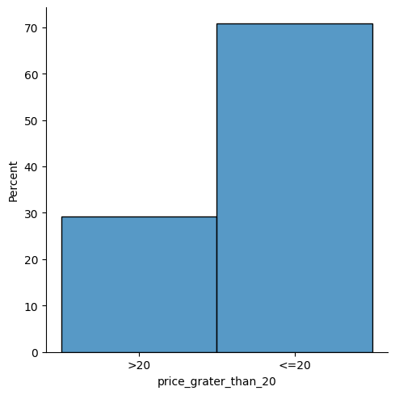

```python
# Create a sub data set (DataFrame) for only order_id and cost_of_the_order
df = data[['order_id', 'cost_of_the_order']].copy()
# Add a new column price_grater_than_20 which will hold a boolean value of true or false
# Use the map method to assign True(>20) or False(<=20) in the new price_grater_than_20 column
df['price_grater_than_20'] = (data['cost_of_the_order'] > 20).map({False: '<=20', True: '>20'})
# Create a dist plot with stat='percent' to have 2 columns for each value.
sns.displot(data=df, x='price_grater_than_20', stat='percent');
plt.show()
```

#### **Observations**: To confirm our calculation is correct, generated the above distribution plot using stat='percent'. From this plot, it confirms that it is likely that *29.24%* (rounded) of the orders cost is more than $20.00

### **Question 10**: What is the mean order delivery time? [1 mark]

```
Mean of column:delivery_time is 24.161749209694417



Added to visualize mean, median and mode - not part of original question
```

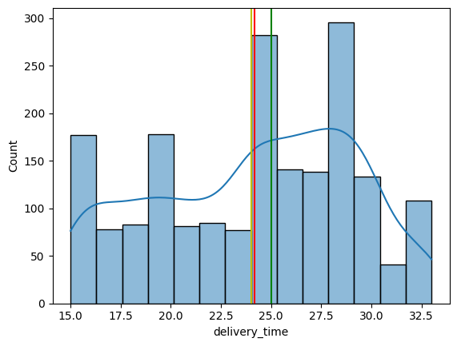

```python
# Display the mean value of the 'delivery_time' column using mean() function
print('Mean of column:delivery_time is',data['delivery_time'].mean())

# Added to visualize mean, median and mode - not part of original question

print ("\n\n\nAdded to visualize mean, median and mode - not part of original question \n\n")


# Define a figure with 1 X 1 subplot with an x-axis
fig, xaxis = plt.subplots(nrows=1, ncols=1,gridspec_kw=None)
# calculate mean, median & mode for 'delivery_time' column
mean=data['delivery_time'].mean()
median=data['delivery_time'].median()
mode=data['delivery_time'].mode().values[0]
# Create a histplot (histogram) for the 'delivery_time' column
sns.histplot(data=data, x="delivery_time", ax=xaxis, kde=True)
# using the pre defined x-axis object create 3 vertical line for mean(red), median (green) and mode (yellow) and lebel the vertical lines as mean, median and mode
xaxis.axvline(mean, color='r', label="Mean")
xaxis.axvline(median, color='g', label="Median")
xaxis.axvline(mode, color='y', label="Mode")
# Display the plot
plt.show()
```

#### **Observations**: From the above canculation we can see that mean for the delivery time is *24.16*

### **Question 11:** The company has decided to give 20% discount vouchers to the top 3 most frequent customers. Find the IDs of these customers and the number of orders they placed. [1 mark]

```python
# We need their total orders in the data set to identify the most frequent customers.
# Doing a group by 'customer_id' and a count for 'order_id' in the dataset will provide the answer. Print the list of cutomer_id and count of order_id in descending order.
data.groupby(['customer_id'])['order_id'].count().sort_values(ascending=False)
```

| customer_id | order_id |
| --- | --- |
| 52832 | 13 |
| 47440 | 10 |
| 83287 | 9 |
| 250494 | 8 |
| 65009 | 7 |
| ... | ... |
| 105903 | 1 |
| 105992 | 1 |
| 106006 | 1 |
| 106324 | 1 |
| 405334 | 1 |

1200 rows × 1 columns

**dtype:** int64

#### **Observations**: From the above table (sorted by descending order of order_count), we can find the top 3 customer_id and the total number of orders they placed.

1. Customer Id: 52832, number of orders: 13
2. Customer Id: 47440, number of orders: 10
3. Customer Id: 83287, number of orders: 9

### **Question 12**: Perform a multivariate analysis to explore relationships between the important variables in the dataset. (It is a good idea to explore relations between numerical variables as well as relations between numerical and categorical variables) [10 marks]

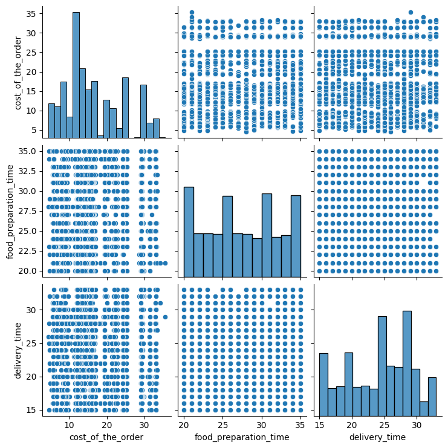

```python
# First, we must do pairwise relationships between continuous/numerical variables within the data set
# cost_of_the_order Vs. food_preparation_time Vs. delivery_time
sns.pairplot(data=data[['cost_of_the_order', 'food_preparation_time', 'delivery_time']])
```

**Observations**: From this plot, we do not see any strong relationships between the 3 numerical variables ['cost_of_the_order,' 'food_preparation_time,' 'delivery_time']. Thus, it appears that these variables may not be directly connected.

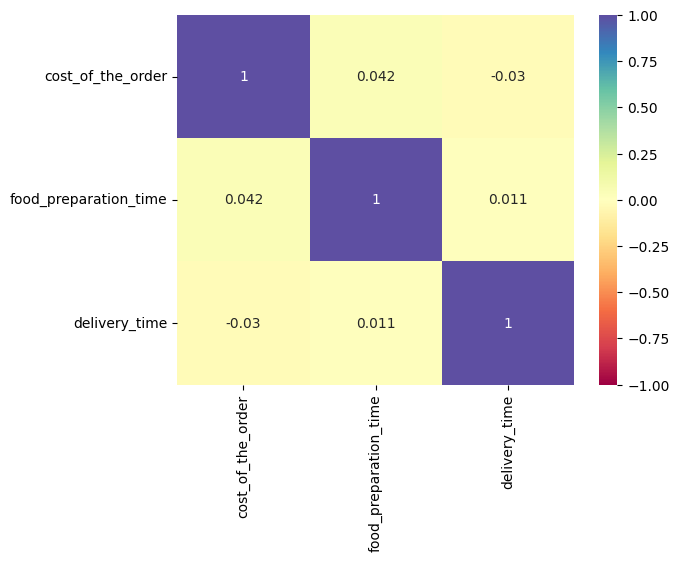

```python
# To confirm, we should create a heatmap for the same numerical variables and check their correlation
# cost_of_the_order Vs. food_preparation_time Vs. delivery_time
sns.heatmap(data=data[['cost_of_the_order', 'food_preparation_time', 'delivery_time']].corr(), annot=True,cmap='Spectral',vmin=-1,vmax=1);
plt.show()
```

**Observations**: The heat map confirms that there is no strong correlation between cost, preparation time, and delivery time. Even if I expected that the order cost may increase food preparation time, the correlation is negligible and has no impact.

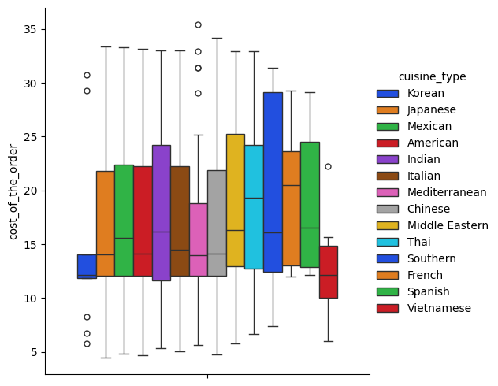

```python
# Next, we should check if the cost of the order has anything to do with the cuisine type.
# Using a catplot, we can generate a boxplot for each cuisine type for the price.
sns.catplot(data=data, y='cost_of_the_order', hue="cuisine_type", kind='box', palette='bright');
plt.xticks(rotation=90)
plt.show()
```

**Observations**:

- Korean food has the slightest variation in cost except for some outliers on both sides.
- The Mediterranean cuisine type has some outliers on the higher side.
- Chinese cuisine has a price variation from very low to very high.
- Vietnamese cuisine never exceeded the price of $25.00
- Costs for all other cuisines vary almost equally.

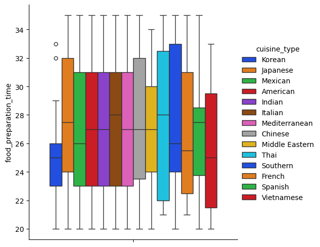

```python
# Next, we should check if the food preparation time is related to the cuisine type.
# Using a catplot, we can generate a boxplot for each cuisine type.
sns.catplot(data=data, y='food_preparation_time', hue="cuisine_type", kind='box', palette='bright');
plt.xticks(rotation=90)
plt.show()
```

**Observations**: This plot shows that food preparation time is equally distributed among cuisine types with slight variations, like it seems Korean food preparation time, on average, is lower with some outliers.

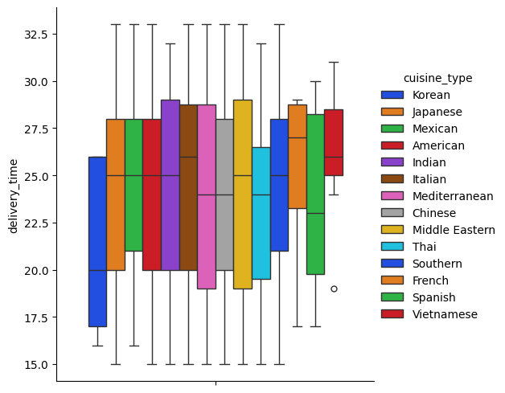

```python
# Is delivery time have any any impact based on cuisine type?
sns.catplot(data=data, y='delivery_time', hue="cuisine_type", kind='box', palette='bright');
plt.xticks(rotation=90)
plt.show()
```

**Observations**: This represents that delivery time also has no significant impact by cuisine type either.

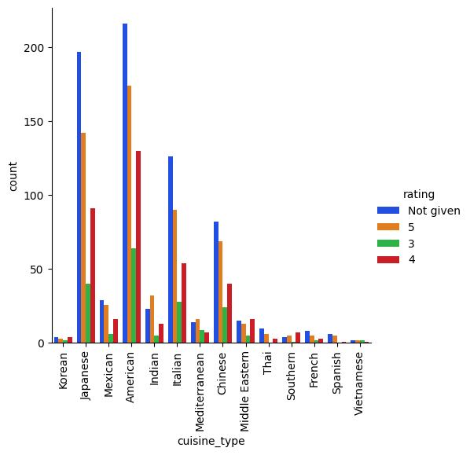

```python
# Checking rating by cuisine type using count plot
sns.catplot(data=data, x='cuisine_type', hue="rating", kind='count', palette='bright');
plt.xticks(rotation=90)
plt.show()
```

**Observations**: No specific trend is visible here either. The ratings follow the same trend as the number of orders for that particular cuisine type. In most cases, customers have not left a rating for all types of cuisines.

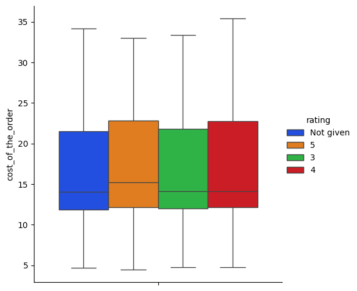

```python
# Checking if the cost of an order has anything to do with the customer's rating
sns.catplot(data=data, y='cost_of_the_order', hue="rating", kind='box', palette='bright');
plt.xticks(rotation=90)
plt.show()
```

**Observations**: It confirms that customers' ratings about their orders have no relationship with the cost of the order. As all ratings and no-rating are almost equally distributed irrespective of the cost.

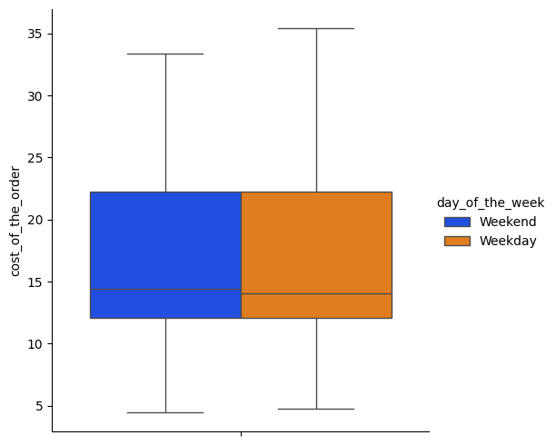

```python
# Does cost vary based on the day of the week
sns.catplot(data=data, y='cost_of_the_order', hue="day_of_the_week", kind='box', palette='bright');
plt.xticks(rotation=90)
plt.show()
```

Observations: Cost is not affected by the weekdays vs weekends except in some negligible cases

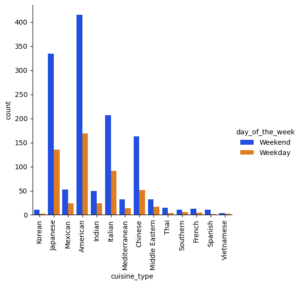

```python
# Is the number of orders vary based on cuisine type and day of the week
sns.catplot(data=data, x='cuisine_type', hue="day_of_the_week", kind='count', palette='bright');
plt.xticks(rotation=90)
plt.show()
```

**Observations**: This graph definitely shows that the number of orders on weekends is higher than on weekdays for every cuisine type. However, the difference is not very significant based on cuisine type between weekends and weekdays.

```python
# Which restaurant(s) receives most of the order?
data.groupby(['restaurant_name'])['order_id'].count().sort_values(ascending=False)
```

| restaurant_name | order_id |
| --- | --- |
| Shake Shack | 219 |
| The Meatball Shop | 132 |
| Blue Ribbon Sushi | 119 |
| Blue Ribbon Fried Chicken | 96 |
| Parm | 68 |
| ... | ... |
| Klong | 1 |
| Kambi Ramen House | 1 |
| Il Bambino | 1 |
| Hunan Manor | 1 |
| Lamarca Pasta | 1 |

178 rows × 1 columns

**dtype:** int64

Observations: The above table shows the most popular restaurants by their number of orders.

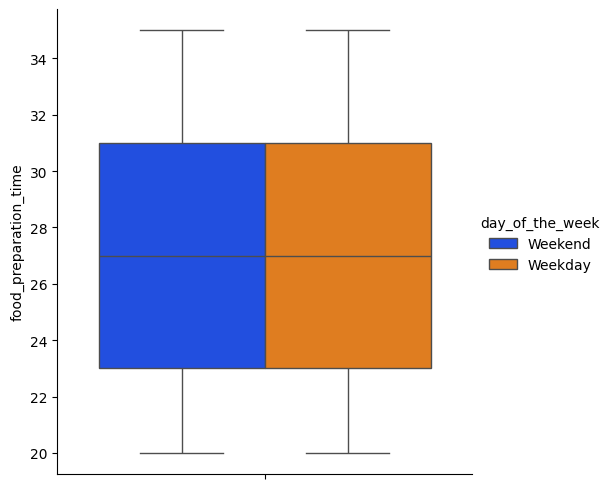

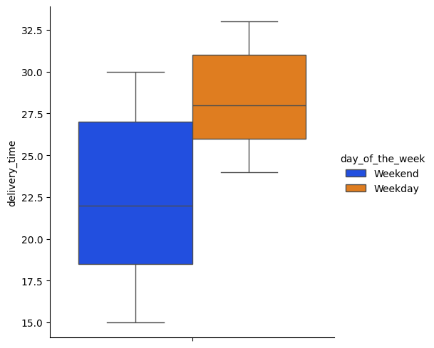

```python
# Check the variations in food preparation and delivery time on weekdays vs. weekends.
sns.catplot(data=data, y='food_preparation_time', hue="day_of_the_week", kind='box', palette='bright');
plt.xticks(rotation=90)
plt.show()
sns.catplot(data=data, y='delivery_time', hue="day_of_the_week", kind='box', palette='bright');
plt.xticks(rotation=90)
plt.show()
```

**Observations**:

- Definitely, food preparation time has no impact between weekdays and weekends
- Delivery time has a significant impact on weekdays compared to weekends. This might result from traffic, rush hour delays, and/or unavailability of delivery persons on weekdays.

*To improve delivery time, the business should consider hiring more staff, providing the team with the necessary support to manage the workload effectively.*

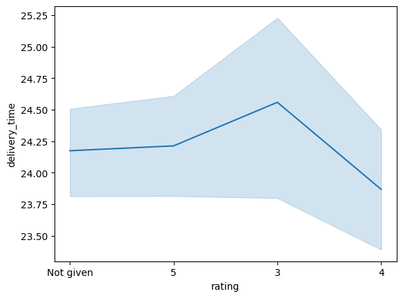

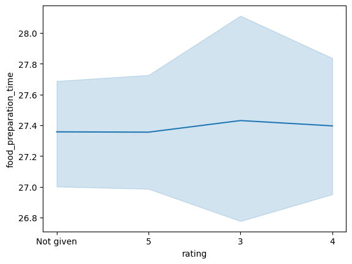

```python
# Check if delivery time and food preparation time has any impact on rating using a line plot
sns.lineplot(data=data, y='delivery_time', x="rating");
plt.show()
sns.lineplot(data=data, y='food_preparation_time', x="rating");
plt.show()
```

### **Question 13:** The company wants to provide a promotional offer in the advertisement of the restaurants. The condition to get the offer is that the restaurants must have a rating count of more than 50 and the average rating should be greater than 4. Find the restaurants fulfilling the criteria to get the promotional offer. [3 marks]

```python
# To identify the restaurants eligible for the promotional offer
# First, we need to remove missing / Not rated data from the dataset

# Create a secondary copy of the original dataset, removing the rows with rating as 'Not provided'.
data_with_no_rating = data[data['rating'] != 'Not given'].copy()

# Convert the 'rating' column from object to int64.
data_with_no_rating['rating'] = data_with_no_rating['rating'].astype(int)

# Filter out the data for restaurants with a rating count greater than 50 and put those data in a new data frame, using group by 'restaurant_name'.
data_filtered = data_with_no_rating.groupby(['restaurant_name']).filter(lambda x: x['rating'].count() > 50)

# Filter out the data for restaurants with average/mean rating count grater than 4.0. Put those data in a new data frame, using group by 'restaurant_name'.
data_filtered2 = data_filtered.groupby(['restaurant_name']).filter(lambda x: x['rating'].mean() > 4.0)

# Finally, print the data group by 'restaurant_name' along with the mean rating in descending order.
data_filtered2.groupby(['restaurant_name'])['rating'].mean().sort_values(ascending=False)
```

| restaurant_name | rating |
| --- | --- |
| The Meatball Shop | 4.511905 |
| Blue Ribbon Fried Chicken | 4.328125 |
| Shake Shack | 4.278195 |
| Blue Ribbon Sushi | 4.219178 |

**dtype:** float64

#### **Observations**: From the above calculations and the result table, we can identify the restaurants that qualify the criteria to receive a promotional offer of the advertisement.

### **Question 14:** The company charges the restaurant 25% on the orders having cost greater than 20 dollars and 15% on the orders having cost greater than 5 dollars. Find the net revenue generated by the company across all orders. [3 marks]

```python
# Calculate total revenue in two steps for ease of understanding.
# First, calculate the revenue for all orders where the cost is greater than $20.00, and charge is 25%.
rev_above_20 = data[data['cost_of_the_order'] > 20.00]['cost_of_the_order'].sum() * 0.25

# Then calculate the revenue for all the orders between $5.00 and $20.00, and the charge is 15%.
rev_between_5_and_20 = data[(data['cost_of_the_order'] > 5.00) & (data['cost_of_the_order'] <= 20.00)]['cost_of_the_order'].sum() * 0.15

# Print the total revenue by adding both > 20.00 and between 5 & 20 revenue.
print('Total revenue=', (rev_above_20 + rev_between_5_and_20))
```

```
Total revenue= 6166.303
```

#### **Observations**: From the above calculation, the total revenue from the given data set will be *$6166.30*

### **Question 15:** The company wants to analyze the total time required to deliver the food. What percentage of orders take more than 60 minutes to get delivered from the time the order is placed? (The food has to be prepared and then delivered.) [2 marks]

```python
# For this, we need to create a new column in the data set called 'total_time,' which is the sum of food_preparation_time and delivery_time.data['total_time'] = data['food_preparation_time'] + data['delivery_time']
data['total_time'] = data['food_preparation_time'] + data['delivery_time']

#data.head()

# Now, we can calculate the number of rows where total_time > 60.
# We can divide the number of rows where total_time > 60 by the total number of rows to get the percentage of orders where the total time is more than 60 min.
((data[data['total_time'] > 60]['total_time'].count() / data['total_time'].count())  * 100).round(decimals=2)
```

```
10.54
```

#### **Observations**: From the above calculation, we can say that at least *10.54%* of the orders took more than 60 minutes to complete from order to delivery.

### **Question 16:** The company wants to analyze the delivery time of the orders on weekdays and weekends. How does the mean delivery time vary during weekdays and weekends? [2 marks]

```
Mean of delivery_time in Weekday's 28.34
Mean of delivery_time in Weekend's 22.47
```

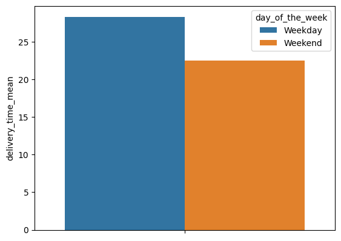

```python
# Calculate and print the mean delivery time on weekdays and weekends.
print('Mean of delivery_time in Weekday\'s',data[data['day_of_the_week'] == 'Weekday']['delivery_time'].mean().round(decimals=2))
print('Mean of delivery_time in Weekend\'s',data[data['day_of_the_week'] == 'Weekend']['delivery_time'].mean().round(decimals=2))

# To plot the variation in mean, we can create a secondary dataset - data_delivery_time_mean from the original dataset for - day_of_the_week.
data_delivery_time_mean = data.groupby(['day_of_the_week'])['delivery_time'].mean(numeric_only=True).reset_index()
data_delivery_time_mean.rename(columns={'delivery_time': 'delivery_time_mean'}, inplace=True)

# We can visualize the difference in the mean by creating a barplot for two mean values for Weekdays and Weekends.
sns.barplot(data=data_delivery_time_mean, y='delivery_time_mean', hue='day_of_the_week')
plt.show()
```

## **Recommendations**:

- The business should consider the most popular cuisine types and restaurants and keep dedicated resources to serve the demand during peak hours.
- To improve delivery time, on weekdays, the business should consider hiring more staff, providing the team with the necessary support to manage the workload effectively (optimal and planned pickup and delivery).
- The business should look at the relationship between rating and total time (food preparation time + delivery time). For some restaurants, this time may impact the number of orders and ratings. Taking steps to improve the total time from order placement to delivery may increase the number of orders and improve ratings.